# 320final

## Age and Skepticism Towards Corporate Data Use

#### Motivation

Technology has become an increasingly integral part of everyday life. Most Americans use several apps and web browsers to access the internet each day. But these apps and browsers provide very little transparency about what data they collect from users and what they do with that data. In recent years there has been more of a push for the government to become more involved in regulating what corporations can do with their users’ data in order to protect users. I propose research on how feelings of skepticism towards how private corporations use consumer data vary among different age groups and levels of digital knowledge by exploring how age affects one's feelings towards what a company does with a customer's data and private information.

This is an important topic to study because despite the high usage of technology there is very little regulation of tech companies from the federal government. Technology companies have been granted a large amount of freedom in how they conduct business. I believe exploring this research question will bring light to why this has been the case for so long. This question will also provide information on how much of a priority these policies are for younger voters.

#### Hypothesis

I believe that when looking at the 2019 poll, as respondent age increases one is more likely to feel more skeptical of how a private corporation uses their digital data. With older individuals many barriers exist that prevent the acceptance of new technologies. For example, older individuals did not grow up with many modern day technologies and are more hesitant to adopt these technologies into their everyday life. A 2006 study by the the Center for Research and Education on Aging and Technology Enhancement found that older adults were “less likely than younger adults to use technology in general, computers, and the World Wide Web” (Czaja et al.). I predict that this lack of use might create more general skepticism of technology and technology companies' use of private information.

Conversely, younger individuals have grown up surrounded by technology and are more likely to see how their data can be used in ways that might benefit them. For example, a younger individual may be more likely to think that a company’s collection of data is appropriate because they enjoy how their data is used to create focused advertisements and customized social media pages. This compared to an older individual who doesn't use the internet as much may feel that the accumulation of their personal data is unnecessary, invasive and therefore inappropriate.

I also hypothesize that controlling for digital knowledge among the respondents will demonstrate an interactive relationship between the variables. I believe that individuals with more digital knowledge regardless of age will be more likely to support government regulation of digital privacy. I predict that this will be because individuals with higher digital knowledge will be more frightened of the magnitude at which private companies are collecting and storing digital data on consumers as opposed to those with less digital knowledge who might be indifferent.

For these reasons I predict that as respondents' age increases, respondents are more likely to be skeptical of how a private corporation uses their digital data. Interactively, I predict that as respondents' digital knowledge increases, they are more likely to be skeptical of these same practices.

#### Approach

For this research I will look at survey results that assess the respondents' skepticism towards how private corporations use their private information and data. This will provide valuable insight into how younger individuals view private corporations' use of consumer data. I believe that this could indicate the younger electorate's desire for the government to implement policy regulating how companies use customer data, the respondents level of skepticism will be the dependent variable. I will use the age group of the respondents as the independent variable. The respondents digital knowledge will be the control variable. I will attempt to find if there is a relationship between the respondents' age and their level of skepticism towards how corporations use digital data.

For this research I plan on using Pew Research Center’s American Trends Panel Wave 49 which provides data from a survey that assesses respondents digital knowledge and opinions towards data usage and privacy. Several questions provide a score that demonstrates the respondents digital knowledge. Further, one's level of skepticism can be assessed through their responses to the questions in the survey (Fig. 1).

```python
import pandas as pd
import numpy as np
import statsmodels.api as sm
from patsy import dmatrices
data = pd.read_csv("ATP_W49.csv")
```

Figure 1. Survey measuring respondent’s skepticism towards how corporations use consumer data.

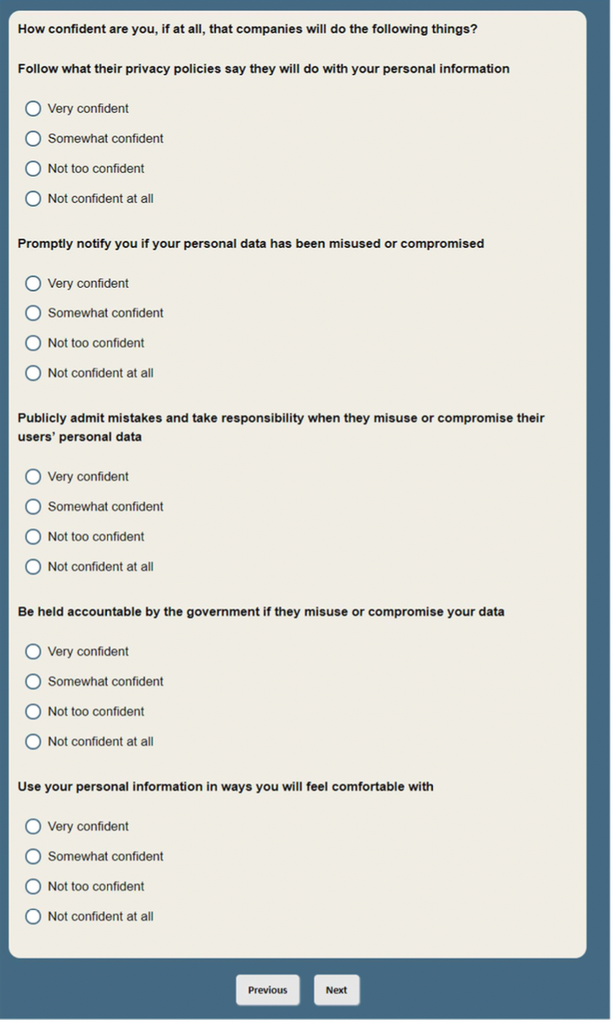

To explore my hypotheses I use an OLS model. The dependent variable of interest is the respondents level of skepticism towards how corporations use consumer data. This value is a continuous value from 5-20 compiled from respondents' answers to a series of five questions regarding how they perceive a corporation would act in a few scenarios regarding consumer privacy. A greater score represents a greater skepticism towards how a corporation handles consumer data while a lower score represents no skepticism.

```python
data["PP5a_W49"] = data["PP5a_W49"].replace(99, np.nan)
data["PP5b_W49"] = data["PP5b_W49"].replace(99, np.nan)
data["PP5c_W49"] = data["PP5c_W49"].replace(99, np.nan)
data["PP5d_W49"] = data["PP5d_W49"].replace(99, np.nan)
data["PP5e_W49"] = data["PP5e_W49"].replace(99, np.nan)
```

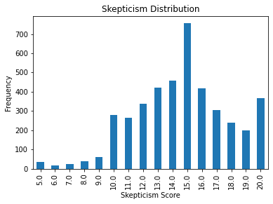

```python
data["pp5all"] = data["PP5a_W49"] + data["PP5b_W49"] + data["PP5c_W49"] + data["PP5d_W49"] + data["PP5e_W49"]
data.groupby(["pp5all"])["pp5all"].count().plot(kind="bar", xlabel="Skepticism Score", ylabel="Frequency",
                                                         title="Skepticism Distribution")
```

Figure 2: Histogram showing the distribution of respondents' skepticism towards how a private corporation uses their data.

The independent variable was the respondents age group (18-29, 30-49, 50-64, 65+).

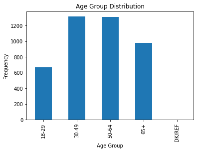

```python
data["Age_Group"] = data["F_AGECAT"].replace({1: "18-29", 2: "30-49", 3: "50-64", 4: "65+", 99: "DK/REF"})
data.groupby(["Age_Group"])["Age_Group"].count().plot(kind="bar", xlabel="Age Group", ylabel="Frequency", title="Age Group Distribution")
```

Figure 3: Bar plot demonstrating the distribution of respondents age groups

I also control digital knowledge. Digital knowledge is a score from 0-10 representing the amount of correct answers on a ten question digital literacy quiz. Questions pertained to vocabulary such as “cookies”, “privacy policy” and other questions related to technology. The average score on this quiz was 4.13. I explored the relationship between age and skepticism for those having below average scores and above average scores on this quiz.

```python
mean_knowledge = data["TOTALKNOW_W49"].mean()
mean_knowledge
```

```
4.132490636704119
```

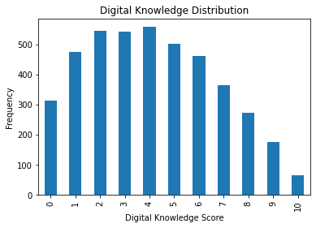

```python
data.groupby(["TOTALKNOW_W49"])["TOTALKNOW_W49"].count().plot(kind="bar", xlabel="Digital Knowledge Score",
                                                         ylabel="Frequency", title="Digital Knowledge Distribution")
```

Figure 4: Histogram demonstrating the distribution of respondents' digital knowledge.

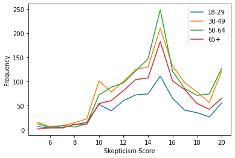

```python
ax = data[data["Age_Group"] == "18-29"].groupby(["pp5all"])["pp5all"].count().plot(kind="line")
ax = data[data["Age_Group"] == "30-49"].groupby(["pp5all"])["pp5all"].count().plot(kind="line", ax=ax)
ax = data[data["Age_Group"] == "50-64"].groupby(["pp5all"])["pp5all"].count().plot(kind="line", ax=ax)
ax = data[data["Age_Group"] == "65+"].groupby(["pp5all"])["pp5all"].count().plot(kind="line", ax=ax)
ax.legend(["18-29", "30-49", "50-64", "65+"])
ax.set_xlabel("Skepticism Score")
ax.set_ylabel("Frequency")
```

Figure 5: Skepticism Distribution for Each Age Group

#### Findings

```python
y, X = dmatrices('pp5all ~ Age_Group', data=data, return_type='dataframe')

mod = sm.OLS(y, X)
res = mod.fit()

print(res.summary())
```

```
                            OLS Regression Results
==============================================================================
Dep. Variable:                 pp5all   R-squared:                       0.003
Model:                            OLS   Adj. R-squared:                  0.002
Method:                 Least Squares   F-statistic:                     2.863
Date:                Fri, 16 Dec 2022   Prob (F-statistic):             0.0221
Time:                        23:40:37   Log-Likelihood:                -10839.
No. Observations:                4220   AIC:                         2.169e+04
Df Residuals:                    4215   BIC:                         2.172e+04
Df Model:                           4
Covariance Type:            nonrobust
=======================================================================================
                          coef    std err          t      P>|t|      [0.025      0.975]
---------------------------------------------------------------------------------------
Intercept              14.3043      0.122    116.960      0.000      14.065      14.544
Age_Group[T.30-49]      0.2273      0.151      1.510      0.131      -0.068       0.523
Age_Group[T.50-64]      0.4746      0.151      3.153      0.002       0.179       0.770
Age_Group[T.65+]        0.3322      0.159      2.088      0.037       0.020       0.644
Age_Group[T.DK/REF]     2.1957      2.237      0.982      0.326      -2.190       6.581
==============================================================================
Omnibus:                       36.098   Durbin-Watson:                   2.009
Prob(Omnibus):                  0.000   Jarque-Bera (JB):               36.417
Skew:                          -0.217   Prob(JB):                     1.24e-08
Kurtosis:                       2.863   Cond. No.                         51.4
==============================================================================

Notes:
[1] Standard Errors assume that the covariance matrix of the errors is correctly specified.
```

Table 1: Summary of linear regression coefficients and significance for each age group

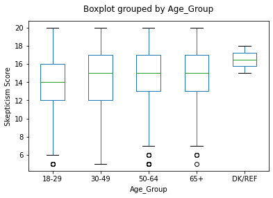

```python
x = data.boxplot("pp5all", "Age_Group", grid=False)
x.set_title("")
x.set_ylabel("Skepticism Score")
```

Figure 6: Box plot showing how skepticism of respondents changes depending on the respondents age group.

```python
data["above_avg_intel"] = data["TOTALKNOW_W49"].apply(lambda x : 1 if x > mean_knowledge else 0)

y, X = dmatrices('pp5all ~ Age_Group + above_avg_intel', data=data, return_type='dataframe')

mod = sm.OLS(y, X)
res = mod.fit()

print(res.summary())
```

```
                            OLS Regression Results
==============================================================================
Dep. Variable:                 pp5all   R-squared:                       0.016
Model:                            OLS   Adj. R-squared:                  0.015
Method:                 Least Squares   F-statistic:                     13.82
Date:                Fri, 16 Dec 2022   Prob (F-statistic):           2.05e-13
Time:                        23:40:38   Log-Likelihood:                -10810.
No. Observations:                4220   AIC:                         2.163e+04
Df Residuals:                    4214   BIC:                         2.167e+04
Df Model:                           5
Covariance Type:            nonrobust
=======================================================================================
                          coef    std err          t      P>|t|      [0.025      0.975]
---------------------------------------------------------------------------------------
Intercept              13.9197      0.132    105.728      0.000      13.662      14.178
Age_Group[T.30-49]      0.2183      0.150      1.460      0.144      -0.075       0.512
Age_Group[T.50-64]      0.5654      0.150      3.768      0.000       0.271       0.860
Age_Group[T.65+]        0.4800      0.159      3.014      0.003       0.168       0.792
Age_Group[T.DK/REF]     2.5803      2.223      1.161      0.246      -1.777       6.938
above_avg_intel         0.7501      0.099      7.582      0.000       0.556       0.944
==============================================================================
Omnibus:                       28.159   Durbin-Watson:                   2.018
Prob(Omnibus):                  0.000   Jarque-Bera (JB):               28.192
Skew:                          -0.188   Prob(JB):                     7.55e-07
Kurtosis:                       2.863   Cond. No.                         55.9
==============================================================================

Notes:
[1] Standard Errors assume that the covariance matrix of the errors is correctly specified.
```

Table 2: Summary of linear regression coefficients and significance for each age group after the control variable indicating if respondent has above/below average digital knowledge.

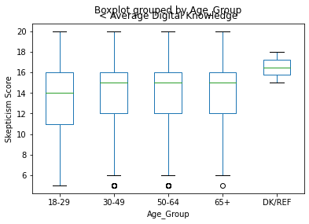

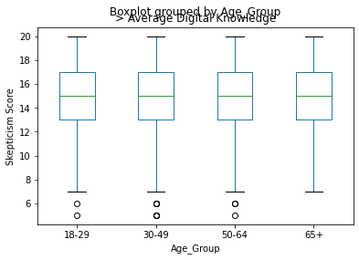

```python
x = data[data["TOTALKNOW_W49"] < mean_knowledge].boxplot("pp5all", "Age_Group", grid=False)
x.set_title("< Average Digital Knowledge")
x.set_ylabel("Skepticism Score")
x = data[data["TOTALKNOW_W49"] > mean_knowledge].boxplot("pp5all", "Age_Group", grid=False)
x.set_title("> Average Digital Knowledge")
x.set_ylabel("Skepticism Score")
```

Figures 7 and 8: Box plots showing how skepticism of respondents changes depending on the respondents age group when respondents have below average digital knowledge and above average digital knowledge respectively.

Table three also shows that the realtionship between digital knowledge and skepticism is also positive and statistically significant.

```python
y, X = dmatrices('pp5all ~ TOTALKNOW_W49', data=data, return_type='dataframe')

mod = sm.OLS(y, X)
res = mod.fit()

print(res.summary())
```

```
                            OLS Regression Results
==============================================================================
Dep. Variable:                 pp5all   R-squared:                       0.016
Model:                            OLS   Adj. R-squared:                  0.015
Method:                 Least Squares   F-statistic:                     66.76
Date:                Fri, 16 Dec 2022   Prob (F-statistic):           4.02e-16
Time:                        23:40:39   Log-Likelihood:                -10812.
No. Observations:                4220   AIC:                         2.163e+04
Df Residuals:                    4218   BIC:                         2.164e+04
Df Model:                           1
Covariance Type:            nonrobust
=================================================================================
                    coef    std err          t      P>|t|      [0.025      0.975]
---------------------------------------------------------------------------------
Intercept        13.9634      0.091    152.948      0.000      13.784      14.142
TOTALKNOW_W49     0.1524      0.019      8.171      0.000       0.116       0.189
==============================================================================
Omnibus:                       27.533   Durbin-Watson:                   2.017
Prob(Omnibus):                  0.000   Jarque-Bera (JB):               27.600
Skew:                          -0.187   Prob(JB):                     1.02e-06
Kurtosis:                       2.868   Cond. No.                         9.53
==============================================================================

Notes:
[1] Standard Errors assume that the covariance matrix of the errors is correctly specified.
```

Table 3: Summary of linear regression coefficients and significance for the effect of digital knowledge on skepticism.

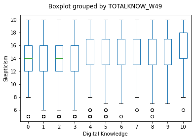

```python
x = data.boxplot("pp5all", "TOTALKNOW_W49", grid=False)
x.set_xlabel("Digital Knowledge")
x.set_ylabel("Skepticism")
x.set_title("")
```

Figure 9: Box plot showing how skepticism of respondents changes depending on the respondents Digital Knowledge.